# Overview

Jumpman23 is an on-demand delivery platform connecting “Jumpmen” and customers purchasing a variety of goods. It sends Jumpmen to merchants to purchase and pick up any items requested by the customer. Jumpman23 is growing fast and has just launched in its newest market - New York City.

# Objective

Identify the potential data integrity issues in the provided dataset and their impacts on the analysis Understand the performance of Jumpman23’s newest market in New York City and find out growth opportunities

```r
library("psych")
DF<-read.csv("C:\\Users\\soham\\Desktop\\analyze_me.csv",stringsAsFactors = TRUE)
describe(DF)
```

```
##                                      vars    n       mean        sd
## delivery_id                             1 5983 1379495.07  64593.97
## customer_id                             2 5983  176472.60 116414.49
## jumpman_id                              3 5983  102661.60  48607.21
## vehicle_type*                           4 5983       1.62      1.43
## pickup_place*                           5 5983     498.19    249.28
## place_category*                         6 5983      22.95     16.90
## item_name*                              7 5983     881.01    736.82
## item_quantity                           8 4753       1.25      0.79
## item_category_name*                     9 5983     310.68    259.61
## how_long_it_took_to_order*             10 5983     668.49    845.52
## pickup_lat                             11 5983      40.74      0.02
## pickup_lon                             12 5983     -73.99      0.01
## dropoff_lat                            13 5983      40.74      0.03
## dropoff_lon                            14 5983     -73.99      0.02
## when_the_delivery_started*             15 5983    2614.87   1502.22
## when_the_Jumpman_arrived_at_pickup*    16 5983    2148.76   1465.10
## when_the_Jumpman_left_pickup*          17 5983    2148.15   1464.50
## when_the_Jumpman_arrived_at_dropoff*   18 5983    2615.11   1502.20
##                                          median    trimmed       mad
## delivery_id                          1375689.00 1378959.55  83133.83
## customer_id                           131093.00  167683.27 103009.57
## jumpman_id                            113364.00  105295.28  58380.34
## vehicle_type*                              1.00       1.23      0.00
## pickup_place*                            546.00     506.62    308.38
## place_category*                           21.00      21.94     19.27
## item_name*                               795.00     837.12   1057.09
## item_quantity                              1.00       1.08      0.00
## item_category_name*                      267.00     299.70    394.37
## how_long_it_took_to_order*                41.00     543.15     59.30
## pickup_lat                                40.74      40.74      0.02
## pickup_lon                               -73.99     -73.99      0.01
## dropoff_lat                               40.74      40.74      0.03
## dropoff_lon                              -73.99     -73.99      0.02
## when_the_delivery_started*              2608.00    2615.62   1933.31
## when_the_Jumpman_arrived_at_pickup*     2126.00    2127.65   1925.90
## when_the_Jumpman_left_pickup*           2125.00    2127.12   1924.41
## when_the_Jumpman_arrived_at_dropoff*    2608.00    2615.88   1933.31
##                                             min        max     range  skew
## delivery_id                          1271706.00 1491424.00 219718.00  0.08
```

[output cut: 21 more lines]

```
## vehicle_type*                            7.71    0.02
## pickup_place*                           -1.14    3.22
## place_category*                         -1.07    0.22
## item_name*                              -1.28    9.53
## item_quantity                          102.60    0.01
## item_category_name*                     -1.49    3.36
## how_long_it_took_to_order*              -0.74   10.93
## pickup_lat                               0.19    0.00
## pickup_lon                               0.41    0.00
## dropoff_lat                              0.12    0.00
## dropoff_lon                             -0.37    0.00
## when_the_delivery_started*              -1.20   19.42
## when_the_Jumpman_arrived_at_pickup*     -1.26   18.94
## when_the_Jumpman_left_pickup*           -1.26   18.93
## when_the_Jumpman_arrived_at_dropoff*    -1.20   19.42
```

```r
summary(DF)
```

```
##   delivery_id       customer_id       jumpman_id         vehicle_type
##  Min.   :1271706   Min.   :   242   Min.   :  3296   bicycle   :4274
##  1st Qu.:1322793   1st Qu.: 77817   1st Qu.: 60761   car       :1215
##  Median :1375689   Median :131093   Median :113364   motorcycle:  21
##  Mean   :1379495   Mean   :176473   Mean   :102662   scooter   :  75
##  3rd Qu.:1436371   3rd Qu.:293381   3rd Qu.:143807   truck     :  48
##  Max.   :1491424   Max.   :405547   Max.   :181543   van       :  76
##                                                      walker    : 274
##                     pickup_place   place_category        item_name
##  Shake Shack              : 311           : 883               :1230
##  Momofuku Milk Bar        : 186   Italian : 504   Fries       :  76
##  The Meatball Shop        : 184   Burger  : 454   Cheese Fries:  35
##  Blue Ribbon Sushi        : 151   Japanese: 433   Shackburger :  31
##  sweetgreen               : 149   American: 405   Chicken     :  30
##  Blue Ribbon Fried Chicken: 133   Chinese : 332   Shack Burger:  29
##  (Other)                  :4869   (Other) :2972   (Other)     :4552
##  item_quantity     item_category_name   how_long_it_took_to_order
##  Min.   : 1.000             :1230                    :2945
##  1st Qu.: 1.000   Sides     : 193     00:03:20.15586 :   5
##  Median : 1.000   Burgers   : 148     00:02:41.985767:   4
##  Mean   : 1.248   Appetizers: 145     00:05:38.163633:   4
##  3rd Qu.: 1.000   Sandwiches: 123     00:05:52.918337:   4
##  Max.   :16.000   Fries     : 111     00:06:19.883106:   4
##  NA's   :1230     (Other)   :4033     (Other)        :3017
##    pickup_lat      pickup_lon      dropoff_lat     dropoff_lon
##  Min.   :40.67   Min.   :-74.02   Min.   :40.65   Min.   :-74.02
##  1st Qu.:40.72   1st Qu.:-74.00   1st Qu.:40.73   1st Qu.:-74.00
##  Median :40.74   Median :-73.99   Median :40.74   Median :-73.99
##  Mean   :40.74   Mean   :-73.99   Mean   :40.74   Mean   :-73.99
##  3rd Qu.:40.76   3rd Qu.:-73.98   3rd Qu.:40.76   3rd Qu.:-73.97
##  Max.   :40.82   Max.   :-73.92   Max.   :40.85   Max.   :-73.92
##
##               when_the_delivery_started
##  2014-10-26 16:55:46.106588:   5
##  2014-10-03 13:05:42.963848:   4
##  2014-10-03 17:09:45.858769:   4
##  2014-10-05 18:29:24.054569:   4
##  2014-10-08 19:33:52.549234:   4
##  2014-10-12 01:15:42.778777:   4
##  (Other)                   :5958
```

[output cut: 9 more lines]

```
##                            : 550
##  2014-10-26 17:15:44.699287:   5
##  2014-10-03 13:41:37.811864:   4
##  2014-10-03 17:40:35.580467:   4
##  2014-10-05 19:11:53.438725:   4
##  2014-10-08 20:38:07.37508 :   4
##  (Other)                   :5412
##          when_the_Jumpman_arrived_at_dropoff
##  2014-10-26 17:26:44.885842:   5
##  2014-10-03 13:54:59.348929:   4
##  2014-10-03 17:51:37.505765:   4
##  2014-10-05 19:25:03.745486:   4
##  2014-10-08 20:49:29.420191:   4
##  2014-10-12 02:01:28.995306:   4
##  (Other)                   :5958
```

```r
dim(DF)
```

```
## [1] 5983   18
```

# Analysis

The following could be the data integrity issues and how these would impact the analysis: 1. Missing Data: There are lot of missing data. This could bias the analysis, as we might have missed capturing data where we could have got interesting results. 2. Timestamp: After calculating the average speed during the delivery, I got certain deliveries which had an average speed of about 80 mph on bicycles in NYC. Hence, there seems to be an error with the timestamp variable. This would have biased our analyses which were done using the timestamp variables. 3. Repeated values for single orders: When a customer ordered multiple items in a single order, there were multiple rows with one for each item. This could create potential problems with delivery level analysis.

# Converting the timestamps into proper format

```r
DF$when_the_delivery_started=as.POSIXct(strptime(DF$when_the_delivery_started,
                                                 "%Y-%m-%d %H:%M:%S"),
                                        "America/New_York")
DF$when_the_Jumpman_arrived_at_pickup=as.POSIXct(strptime(DF$when_the_Jumpman_arrived_at_pickup,
                                                          "%Y-%m-%d %H:%M:%S"),
                                                 "America/New_York")
DF$when_the_Jumpman_left_pickup=as.POSIXct(strptime(DF$when_the_Jumpman_left_pickup,
                                                    "%Y-%m-%d %H:%M:%S"),
                                           "America/New_York")
DF$when_the_Jumpman_arrived_at_dropoff=as.POSIXct(strptime(DF$when_the_Jumpman_arrived_at_dropoff,
                                                           "%Y-%m-%d %H:%M:%S"),
                                                  "America/New_York")
```

# Columns Added

distance: The distance between pickup places and the dropoff places. prep_time: The time between Jumpmen arrived and left the pickup places. transit_time: The time when Jumpmen deliver orders from the pickup places to the drop off places. total_delivery_time: The time interval from the time when Jumpmen start the delivery to the time when Jumpmen drop off the items to the customers. delivery_speed: The speed of the Jumpmen when delivery orders from pickup places to dropoff places. #Create the column of distance

```r
library(geosphere)
DF$distance <- distHaversine(cbind(DF$dropoff_lat,DF$dropoff_lon),
                             cbind(DF$pickup_lat,DF$pickup_lon))

library(udunits2) #Convert the unit of the distance from meters to miles
DF$distance <- ud.convert(DF$distance, "m","miles")
```

```r
#Create the column of prep_time
DF$prep_time <- difftime(DF$when_the_Jumpman_left_pickup,
                         DF$when_the_Jumpman_arrived_at_pickup,
                         units="mins")

#Create the column of transit_time
DF$transit_time <- difftime(DF$when_the_Jumpman_arrived_at_dropoff,
                            DF$when_the_Jumpman_left_pickup,
                            units="mins")

#Create the column of total_delivery_time
DF$total_delivery_time <- difftime(DF$when_the_Jumpman_arrived_at_dropoff,
                                   DF$when_the_delivery_started,
                                   units="mins")
```

```r
#Create the column of delivery_speed
DF$delivery_speed <- DF$distance/as.numeric(DF$transit_time)
library(udunits2) #Convert the unit of the speed to MPH
DF$delivery_speed <- ud.convert(DF$delivery_speed, "miles/min","miles/hr")

#Remove the repeated records and keep one order per delivery id
library(dplyr)
DF_new <- distinct(DF, delivery_id, .keep_all = TRUE)
```

```r
#Customer data
library(lubridate)
```

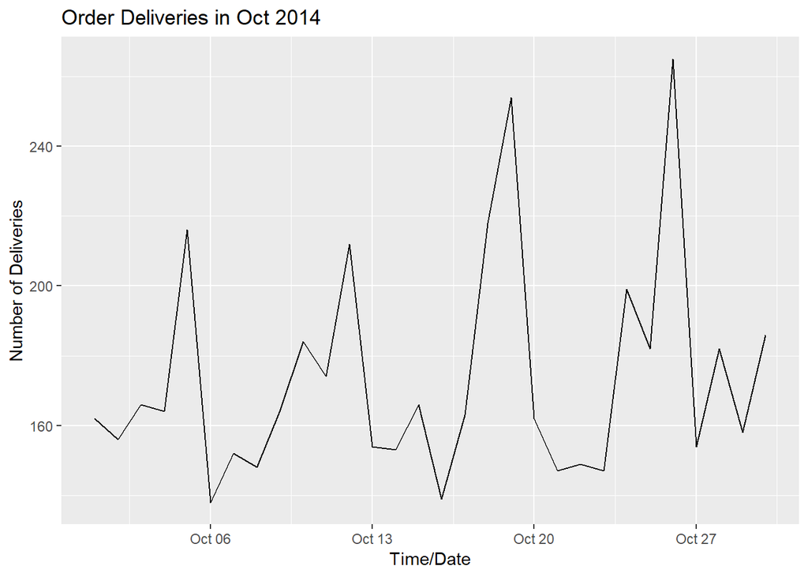

```r
library(ggplot2)
#Delivery trends by date
ggplot(DF_new,aes(x=date(when_the_delivery_started), 1,group=1)) +
  stat_summary(fun.y = sum,geom = "line")+
  ggtitle("Order Deliveries in Oct 2014")+
  ylab("Number of Deliveries")+xlab("Time/Date")
```

```r
library(leaflet)
m <- leaflet() %>%
  addProviderTiles(providers$CartoDB.Positron) %>%
  addCircles(DF_new$dropoff_lon, DF_new$dropoff_lat) %>%
  addMarkers(DF_new$dropoff_lon, DF_new$dropoff_lat,
             clusterOptions = markerClusterOptions()
  )
m
```

[interactive chart not shown]

# Delivery trends by day of the week

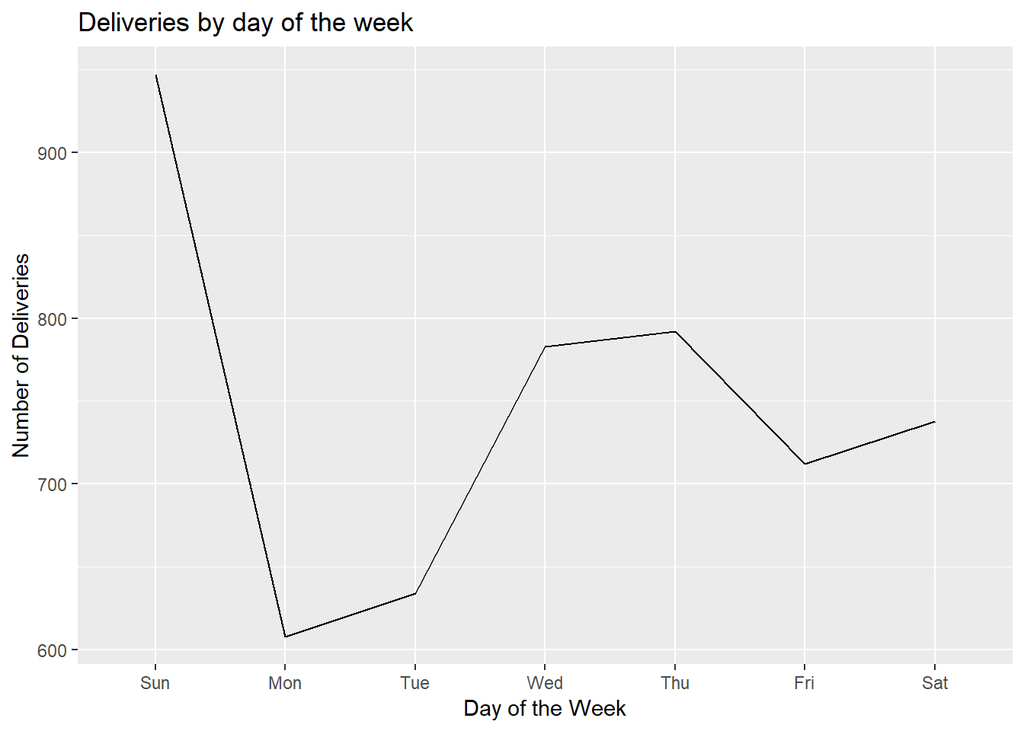

```r
library(lubridate)
library(ggplot2)
ggplot(DF_new,aes(x=wday(when_the_delivery_started,label=T), 1,group=1)) +
  stat_summary(fun.y = sum,geom = "line")+
  ggtitle("Deliveries by day of the week")+
  ylab("Number of Deliveries")+xlab("Day of the Week")
```

# Delivery trends by hour of the day

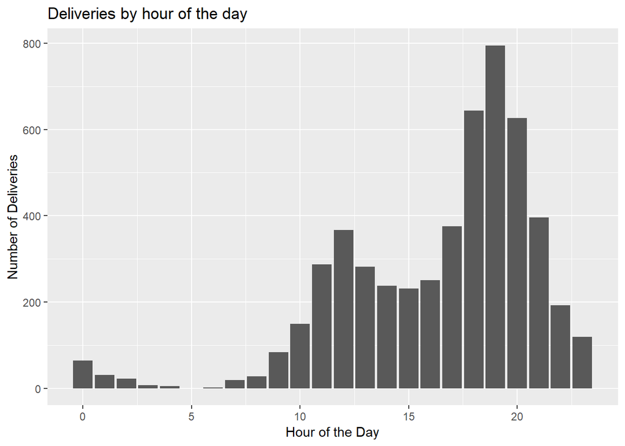

```r
ggplot(DF_new,aes(x=hour(when_the_delivery_started), 1,group=1)) +
  stat_summary(fun.y = sum,geom = "bar")+
  ggtitle("Deliveries by hour of the day")+
  ylab("Number of Deliveries")+xlab("Hour of the Day")
```

# Number of new customers aquired per day

# New customer acquisition

```r
library(sqldf)
```

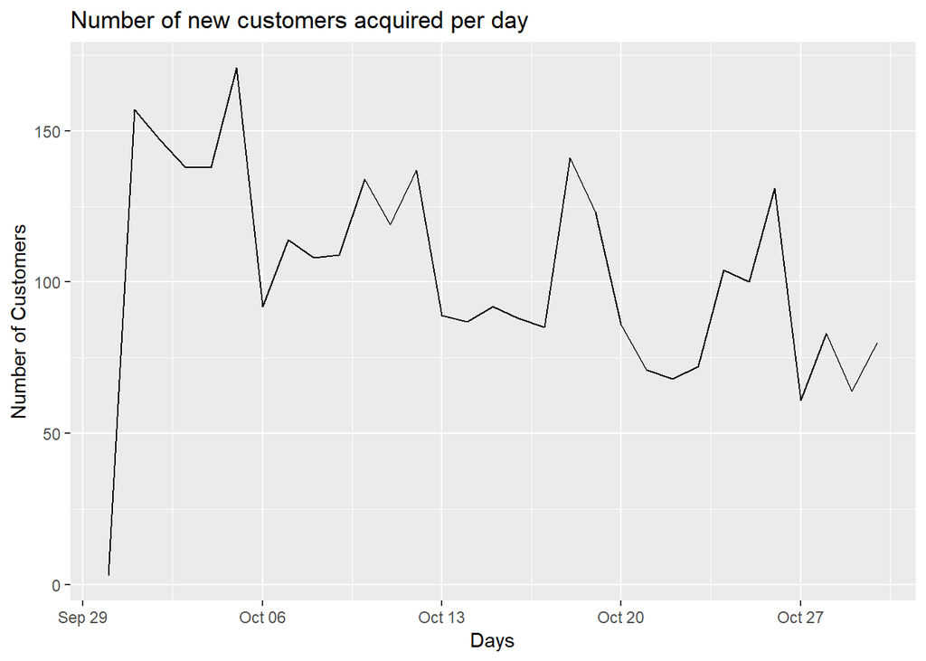

```r
cust_acq <- sqldf(
  "SELECT DISTINCT customer_id, min(when_the_delivery_started) AS when_the_delivery_started
   FROM DF_new
   GROUP BY 1
   ORDER BY 2
  ;"
)
library(ggplot2)
ggplot(cust_acq,aes(x=date(when_the_delivery_started),y=1))+
  stat_summary(fun.y=sum,geom="line")+
  ggtitle("Number of new customers acquired per day")+
  ylab("Number of Customers")+
  xlab("Days")
```

# Customer purchase frequency

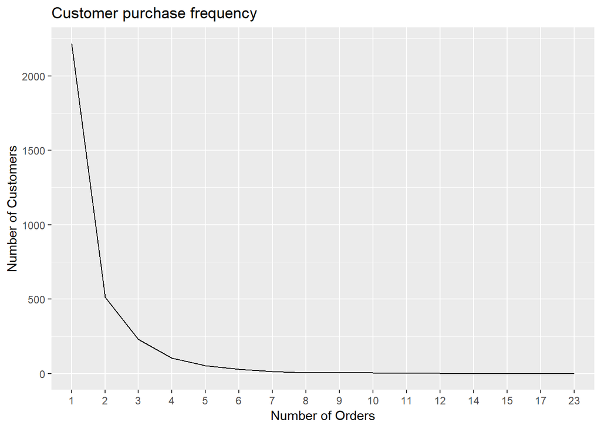

```r
library(sqldf)
PurchaseFreq <- sqldf(
  "SELECT customer_id, COUNT(delivery_id) AS Orders
  FROM DF_new
  GROUP BY 1;"
)
library(ggplot2)
ggplot(data=PurchaseFreq, aes(x=as.factor(Orders), 1, group=1))  +
  stat_summary(fun.y = sum,geom = "line")+
  xlab("Number of Orders") +
  ylab("Number of Customers") +
  ggtitle("Customer purchase frequency")
```

# Merchant analysis

```r
library(leaflet)
m2 <- leaflet() %>%
  addProviderTiles(providers$CartoDB.Positron) %>%
  addCircles(DF_new$pickup_lon, DF_new$pickup_lat, color = 'green') %>%
  addMarkers(DF_new$pickup_lon, DF_new$pickup_lat,
             clusterOptions = markerClusterOptions()
  )
m2
```

[interactive chart not shown]

# Top 10 merchants with most orders

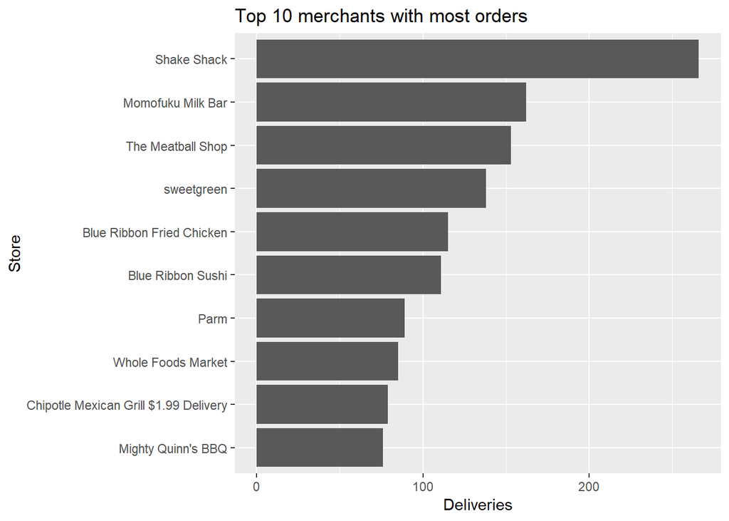

```r
library(sqldf)
top10Store <- sqldf(
  "SELECT pickup_place, COUNT(delivery_id) AS Deliveries
  FROM DF_new
  GROUP BY 1
  ORDER BY 2 DESC
  LIMIT 10;"
)
library(ggplot2)
ggplot(data=top10Store, aes(x=reorder(pickup_place, Deliveries), y=Deliveries)) +
  geom_bar(stat="identity") +  xlab("Store") +
  ylab("Deliveries") +
  ggtitle("Top 10 merchants with most orders") + coord_flip()
```

# Merchants’ preparation time distribution

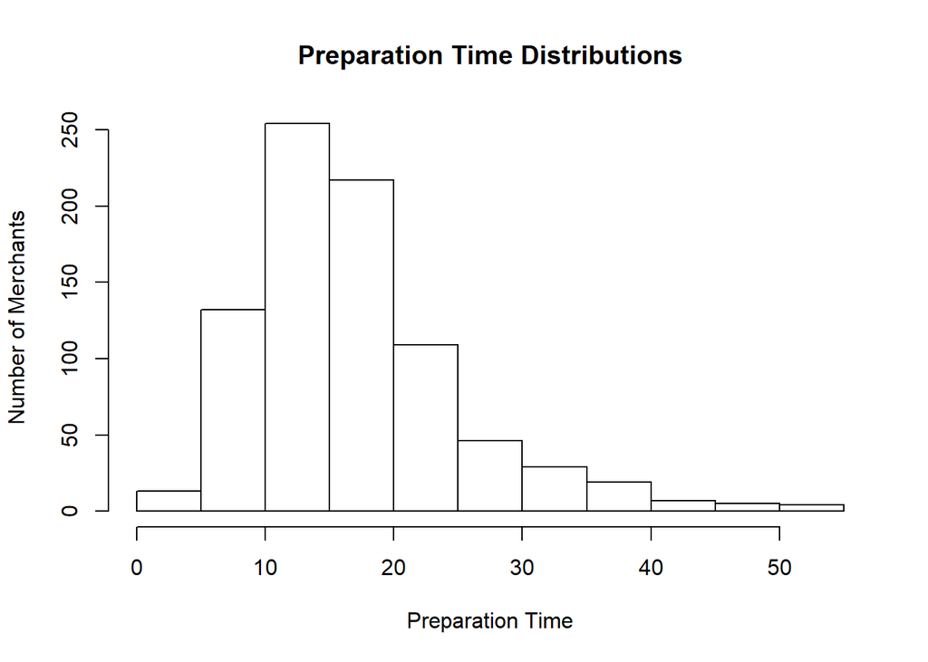

```r
library(sqldf)
prepTime <- sqldf(
  "SELECT pickup_place, avg(prep_time)
   FROM DF_new
   GROUP BY 1
;"
)
hist(prepTime$`avg(prep_time)`,
     main = "Preparation Time Distributions",
     ylab="Number of Merchants",
     xlab="Preparation Time")
```

# ======================================================

# Deliveries by vehicle types

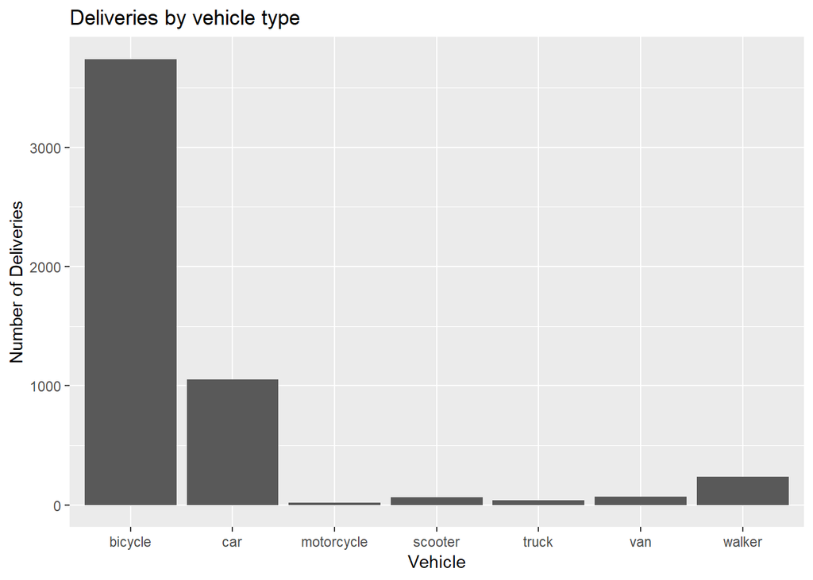

```r
library(ggplot2)
ggplot(DF_new,aes(x=vehicle_type, 1,group=1)) +
  stat_summary(fun.y = sum,geom = "bar")+
  ggtitle("Deliveries by vehicle type")+
  ylab("Number of Deliveries")+xlab("Vehicle")
```

# Delivery Distance

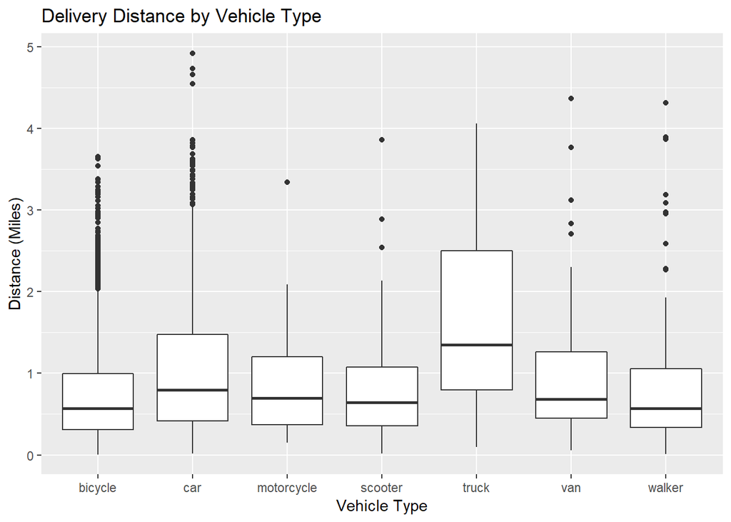

```r
ggplot(DF_new,aes(x=vehicle_type,y=distance))+
  geom_boxplot()+
  ggtitle("Delivery Distance by Vehicle Type")+
  xlab("Vehicle Type")+
  ylab("Distance (Miles)")
```

# Transit Time

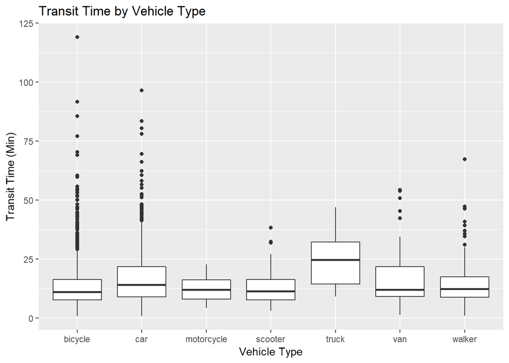

```r
ggplot(DF_new,aes(x=vehicle_type,y=as.numeric(transit_time)))+
  geom_boxplot()+
  ggtitle("Transit Time by Vehicle Type")+
  xlab("Vehicle Type")+
  ylab("Transit Time (Min)")
```

# Vehicle usage by days

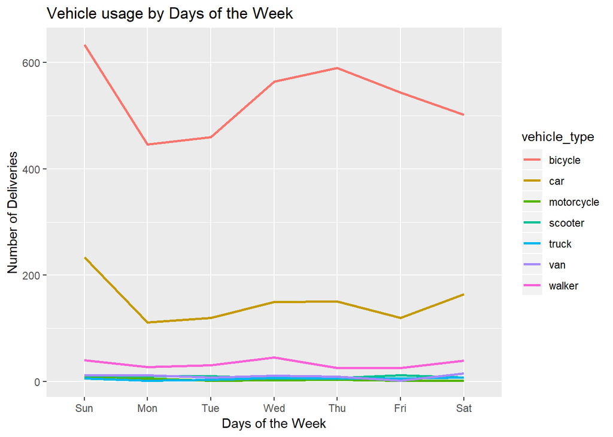

```r
ggplot(DF_new,aes(x=wday(when_the_delivery_started,label=T), 1,group=vehicle_type,color=vehicle_type)) +
  stat_summary(fun.y = sum,geom = "line",size=1)+
  ggtitle("Vehicle usage by Days of the Week")+
  xlab("Days of the Week")+ylab("Number of Deliveries")
```

# Avg delivery speed by vehicle type

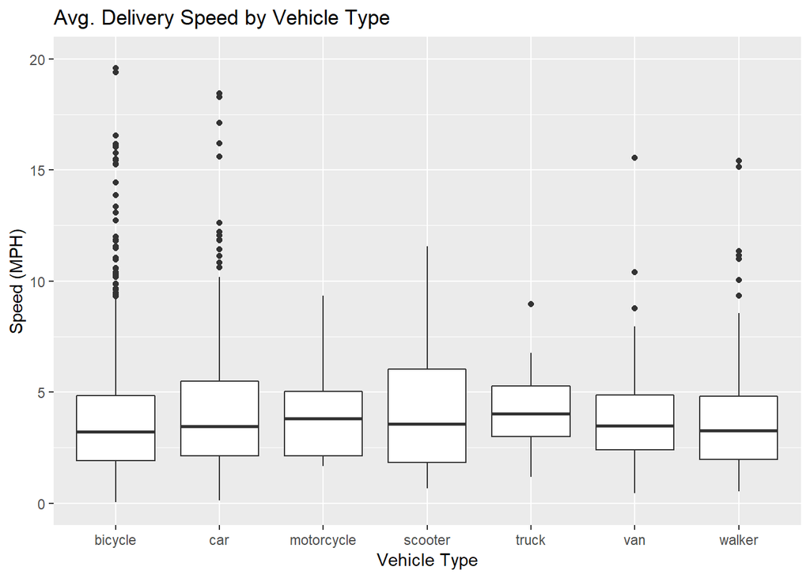

```r
ggplot(DF_new,aes(x=vehicle_type,y=delivery_speed))+
  geom_boxplot()+
  ggtitle("Avg. Delivery Speed by Vehicle Type")+
  xlab("Vehicle Type")+
  ylab("Speed (MPH)")+ylim(0,20)
```

# Insights

# Things to be taken care of:

Removing the duplicates and imputing proper values for those missing values sicne there are a lot of missing values and considering only the complete cases then the data set is redeuced to 3192 objects from 5983 objects.

Taking care of the timestamp values.

We can send out delivery discounts on popular items and stores (such as Shake Shack) or host offline events in the lower Manhattan area. The good time to run campaigns could be Weekends during lunch and dinner time.

For those merchants which need more than 30 minutes of preparation time, we can identify the popular ones with their popular items and purchase them in advance to save the time.

# Metrics

Total Order Deliveries 5214

Total Customers 3192

Total Merchants 898

Total Jumpmen 578

Avg Delivery Time 45 min

Avg Prep Time 18 min

Avg Transit Time 14 min